# **Name: Bhavin Bhatt**

# **Title: Housing Dataset**

## **Section 1 - Loading the dataset**

```python
import pandas as pd
import numpy as np

df = pd.read_csv('/content/housing.csv')
df.head()
```

|  | longitude | latitude | housing_median_age | total_rooms | total_bedrooms | population | households | median_income | median_house_value | ocean_proximity |
| --- | --- | --- | --- | --- | --- | --- | --- | --- | --- | --- |
| 0 | -122.23 | 37.88 | 41.0 | 880.0 | 129.0 | 322.0 | 126.0 | 8.3252 | 452600.0 | NEAR BAY |
| 1 | -122.22 | 37.86 | 21.0 | 7099.0 | 1106.0 | 2401.0 | 1138.0 | 8.3014 | 358500.0 | NEAR BAY |
| 2 | -122.24 | 37.85 | 52.0 | 1467.0 | 190.0 | 496.0 | 177.0 | 7.2574 | 352100.0 | NEAR BAY |
| 3 | -122.25 | 37.85 | 52.0 | 1274.0 | 235.0 | 558.0 | 219.0 | 5.6431 | 341300.0 | NEAR BAY |
| 4 | -122.25 | 37.85 | 52.0 | 1627.0 | 280.0 | 565.0 | 259.0 | 3.8462 | 342200.0 | NEAR BAY |

1.1 Print number of rows and columns

```python
print('Number of rows:',df.shape[0])
print('Number of columns:', df.shape[1])
```

```
Number of rows: 20640
Number of columns: 10
```

1.3 Print the first 5 rows of the dataframe.

```python
print('First 5 rows:')
df.head(5)
```

```
First 5 rows:
```

|  | longitude | latitude | housing_median_age | total_rooms | total_bedrooms | population | households | median_income | median_house_value | ocean_proximity |
| --- | --- | --- | --- | --- | --- | --- | --- | --- | --- | --- |
| 0 | -122.23 | 37.88 | 41.0 | 880.0 | 129.0 | 322.0 | 126.0 | 8.3252 | 452600.0 | NEAR BAY |
| 1 | -122.22 | 37.86 | 21.0 | 7099.0 | 1106.0 | 2401.0 | 1138.0 | 8.3014 | 358500.0 | NEAR BAY |
| 2 | -122.24 | 37.85 | 52.0 | 1467.0 | 190.0 | 496.0 | 177.0 | 7.2574 | 352100.0 | NEAR BAY |
| 3 | -122.25 | 37.85 | 52.0 | 1274.0 | 235.0 | 558.0 | 219.0 | 5.6431 | 341300.0 | NEAR BAY |
| 4 | -122.25 | 37.85 | 52.0 | 1627.0 | 280.0 | 565.0 | 259.0 | 3.8462 | 342200.0 | NEAR BAY |

## **Section 2 -Performing Exploratory Data Analysis on the dataset**

### 2.1 Printing column names and their data types

```python
df.info()
```

```
<class 'pandas.core.frame.DataFrame'>
RangeIndex: 20640 entries, 0 to 20639
Data columns (total 10 columns):
 #   Column              Non-Null Count  Dtype
---  ------              --------------  -----
 0   longitude           20640 non-null  float64
 1   latitude            20640 non-null  float64
 2   housing_median_age  20640 non-null  float64
 3   total_rooms         20640 non-null  float64
 4   total_bedrooms      20433 non-null  float64
 5   population          20640 non-null  float64
 6   households          20640 non-null  float64
 7   median_income       20640 non-null  float64
 8   median_house_value  20640 non-null  float64
 9   ocean_proximity     20640 non-null  object
dtypes: float64(9), object(1)
memory usage: 1.6+ MB
```

### 2.2 For all the numerical columns plot the histogram distribution and write your observations about them. (Except latitude and longitude)

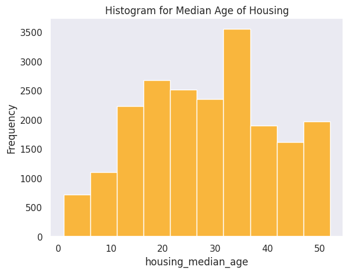

```python
import matplotlib.pyplot as plt
import seaborn as sns
sns.set(style="dark")
sns.histplot(df['housing_median_age'], bins=10, color= 'orange')

#plt.hist(df['housing_median_age'], bins=10, kde=True)
plt.xlabel('housing_median_age')
plt.ylabel('Frequency')
plt.title(f'Histogram for Median Age of Housing')
plt.show()
```

[figure not shown]

```python
import matplotlib.pyplot as plt
import seaborn as sns
sns.set(style="dark")
sns.histplot(df['total_rooms'], bins=40, color= 'orange')

plt.xlabel('total_rooms')
plt.xticks(fontsize=8)

plt.ylabel('Frequency')

plt.title(f'Histogram of Population')
plt.show()
```

- The Histogram plot above describes the column total_rooms which provides the total rooms in houses. It can be seen that the maximum number of rooms of the houses are between 1000-2000 with frequency of 6900 approximately. This is followed by rooms count from 2000-3000 with frequency of about 5500 approximately.

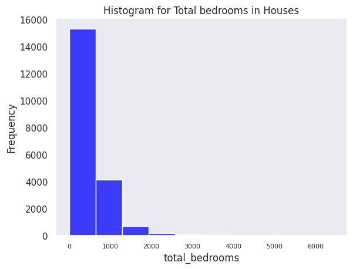

```python
import matplotlib.pyplot as plt
import seaborn as sns
sns.set(style="dark")
sns.histplot(df['total_bedrooms'], bins=10, color= 'blue')

plt.xlabel('total_bedrooms')
plt.xticks(fontsize=8)

plt.ylabel('Frequency')

plt.title(f'Histogram for Total bedrooms in Houses')
plt.show()
```

- The Histogram plot above describes the column total_bedrooms which provides the total bedrooms in houses. It can be seen that the maximum number of bedrooms of the houses are between 0-500 with frequency of 15500 approximately. This is followed by rooms count from 500-1000 with frequency of about 4000 approximately.

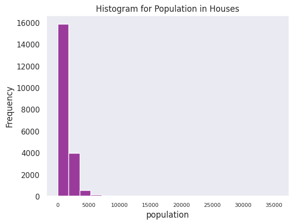

```python
import matplotlib.pyplot as plt
import seaborn as sns
sns.set(style="dark")
sns.histplot(df['population'], bins=20, color= 'purple')

plt.xlabel('population')
plt.xticks(fontsize=8)

plt.ylabel('Frequency')

plt.title(f'Histogram for Population in Houses')
plt.show()
```

- The Histogram plot above describes the column population which provides the total population in blocks around the bay area. It can be seen that maximum number of population falls in between 0-2500 bin category with a frequency of approx 16000 counts.

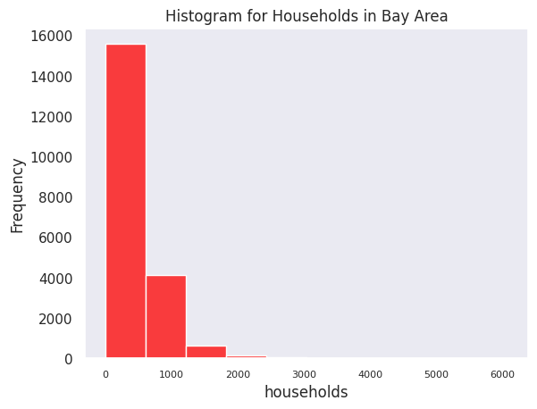

```python
import matplotlib.pyplot as plt
import seaborn as sns
sns.set(style="dark")
sns.histplot(df['households'], bins=10, color= 'red')

plt.xlabel('households')
plt.xticks(fontsize=8)

plt.ylabel('Frequency')

plt.title(f'Histogram for Households in Bay Area')
plt.show()
```

- The Histogram plot above describes the column household which provides the total households around the bay area. Most of the households fall under the category from 0-500 with frequency count of 15800 approximately.

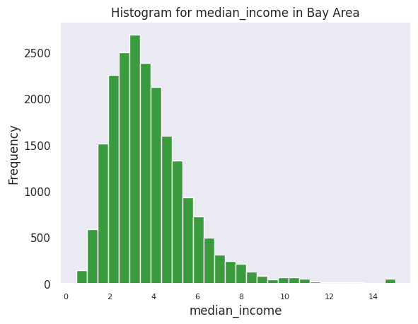

```python
import matplotlib.pyplot as plt
import seaborn as sns
sns.set(style="dark")
sns.histplot(df['median_income'], bins=30, color= 'green')

plt.xlabel('median_income')
plt.xticks(fontsize=8)

plt.ylabel('Frequency')

plt.title(f'Histogram for median_income in Bay Area')
plt.show()
```

- The histogram plot above describes the column median_income of households around the bay area. It can be seen that most of the median income fall in between range 3 to 3.5 with frewuency of about 2700. The second most median income amongst households falls in between range 2.5-3 with frequency of approx 2400.

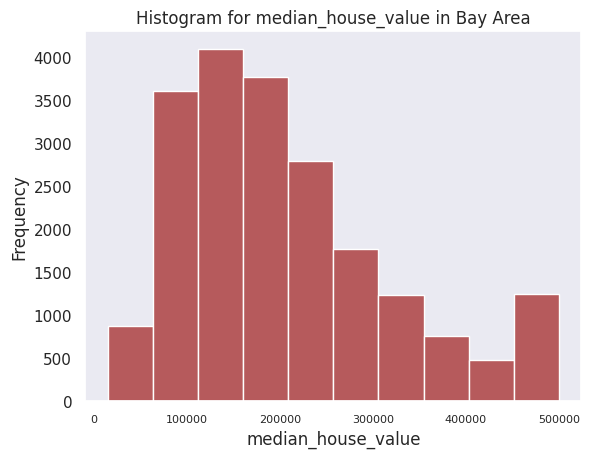

```python
import matplotlib.pyplot as plt
import seaborn as sns
sns.set(style="dark")
sns.histplot(df['median_house_value'], bins=10, color= 'brown')

plt.xlabel('median_house_value')
plt.xticks(fontsize=8)

plt.ylabel('Frequency')

plt.title(f'Histogram for median_house_value in Bay Area')
plt.show()
```

The histogram plot above describes the column median_household_value of households around the bay area. It can be seen that most of the median_household value falls in range 1,00,000-15,00,000 with a frequency of just above 4000. Second highest median household values falls in range 1,50,000 to 2,00,000 with frequency of about 3700 counts.

### 2.3 For all the numerical columns plot the box plots and check if there are outliers in any of the column. (Except latitude and longitude

```python
df.head(5)
```

|  | longitude | latitude | housing_median_age | total_rooms | total_bedrooms | population | households | median_income | median_house_value | ocean_proximity |
| --- | --- | --- | --- | --- | --- | --- | --- | --- | --- | --- |
| 0 | -122.23 | 37.88 | 41.0 | 880.0 | 129.0 | 322.0 | 126.0 | 8.3252 | 452600.0 | NEAR BAY |
| 1 | -122.22 | 37.86 | 21.0 | 7099.0 | 1106.0 | 2401.0 | 1138.0 | 8.3014 | 358500.0 | NEAR BAY |
| 2 | -122.24 | 37.85 | 52.0 | 1467.0 | 190.0 | 496.0 | 177.0 | 7.2574 | 352100.0 | NEAR BAY |
| 3 | -122.25 | 37.85 | 52.0 | 1274.0 | 235.0 | 558.0 | 219.0 | 5.6431 | 341300.0 | NEAR BAY |
| 4 | -122.25 | 37.85 | 52.0 | 1627.0 | 280.0 | 565.0 | 259.0 | 3.8462 | 342200.0 | NEAR BAY |

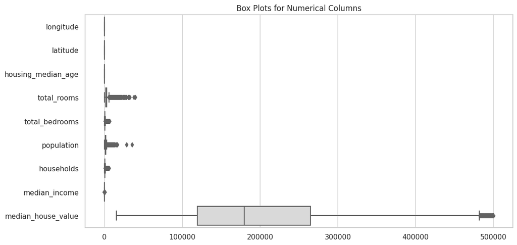

```python
# Select only the numerical columns
import matplotlib.pyplot as plt

import seaborn as sns

numerical_columns = df.select_dtypes(include=['int', 'float'])

# Set up the Seaborn style
sns.set(style="whitegrid")

# Create box plots for all numerical columns
plt.figure(figsize=(12, 6))
sns.boxplot(data=numerical_columns, orient='h', palette='Set3')
plt.title('Box Plots for Numerical Columns')
plt.show()
```

The columns that have outliers are as below:

- total_rooms
- total_bedrooms
- population
- household
- median_income
- median_house_value have outliers.

### 2.4 Plot a heatmap and check whether there is a correlation between different numerical features. Also check the correlation of different features with the target feature median_house_value.

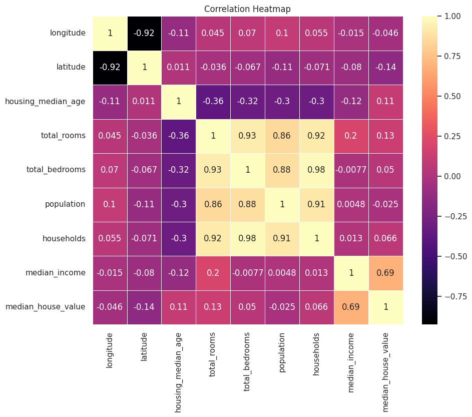

```python
# Calculate the correlation matrix
corr_matrix = df.corr()
sns.set(style="whitegrid")

# Correlation heatmap
plt.figure(figsize=(10, 8))
sns.heatmap(corr_matrix, annot=True, cmap='magma', linewidths=.5)
plt.title('Correlation Heatmap')
plt.show()
```

- Target variable median_house_value is mildly corelated to all but one other features which is median_income. So this feature can be considered as the main feature.
- There is also a strong co-relation between total_rooms and population.
- Another strong co-relation is between total_rooms and households, total_rooms and total_bedrooms.

### 2.5 Plot a barplot to check how many houses are in different subcategories of the feature ‘ocean_proximity'.

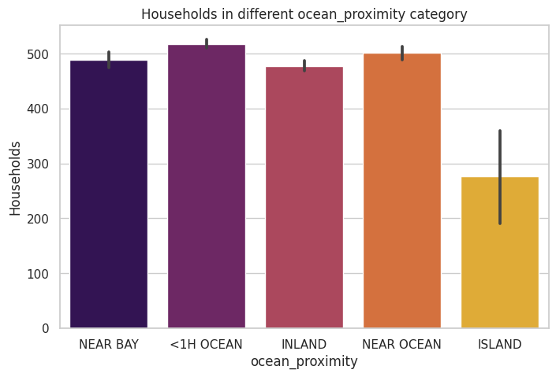

```python
import matplotlib.pyplot as plt
import seaborn as sns

# Set the figure size
plt.figure(figsize=(8, 5))

# Create the bar plot for ocean_proximity
ax = sns.barplot(x=df["ocean_proximity"], y=df["households"], palette="inferno")

# Customize the plot title and axis labels
ax.set_title('Households in different ocean_proximity category')
ax.set(xlabel='ocean_proximity', ylabel='Households')

# Rotate the y-axis labels for better readability
plt.xticks()
plt.show()
```

## **Section 3- Preprocessing the dataset**

### 3.1 Find if there are any NaN values in the dataset.

```python
# Finding Nan values

df.isnull().sum()
```

```
longitude               0
latitude                0
housing_median_age      0
total_rooms             0
total_bedrooms        207
population              0
households              0
median_income           0
median_house_value      0
ocean_proximity         0
dtype: int64
```

- There only 207 NaN values in the total_bedrooms column whereas all other columns in the dataset do not have any Nan values.

### 3.2 Impute the NaN values with the median value of the column.

```python
import pandas as pd

# Replacing NaN values with the median values in total_bedrooms column
total_bedrooms_median = df['total_bedrooms'].median()
df['total_bedrooms'].fillna(total_bedrooms_median, inplace=True)

#Checking the median value of total_bedrooms column
print(total_bedrooms_median)
```

```
435.0
```

```python
#Checking again the null values
df.isnull().sum()
```

```
longitude             0
latitude              0
housing_median_age    0
total_rooms           0
total_bedrooms        0
population            0
households            0
median_income         0
median_house_value    0
ocean_proximity       0
dtype: int64
```

- Thus total_bedrooms column NaN values have been succesfully replaced by the median value of the column and there are no more NaN values in our dataset.

### 3.3 Remove the outlier datapoints from the dataset.

```python
#Removing outliers for total_rooms column
Q1_total_rooms = df['total_rooms'].quantile(0.25)
Q3_total_rooms = df['total_rooms'].quantile(0.75)
IQR = Q3_total_rooms - Q1_total_rooms

df= df[(df['total_rooms'] > Q1_total_rooms - 1.5 * IQR) & (df['total_rooms'] < Q3_total_rooms + 1.5 * IQR)]
```

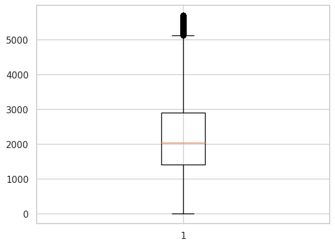

```python
plt.boxplot(df.total_rooms);
```

```python
#Removing outliers for total_bedrooms column
Q1_total_bedrooms = df['total_bedrooms'].quantile(0.25)
Q3_total_bedrooms = df['total_bedrooms'].quantile(0.75)
IQR = Q3_total_bedrooms - Q1_total_bedrooms

df= df[(df['total_bedrooms'] > Q1_total_bedrooms - 1.5 * IQR) & (df['total_bedrooms'] < Q3_total_bedrooms + 1.5 * IQR)]
```

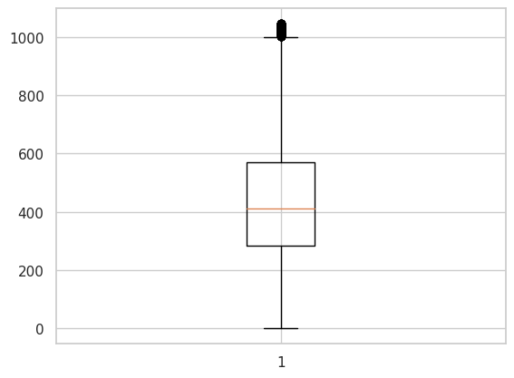

```python
plt.boxplot(df.total_bedrooms);
```

```python
#Removing outliers for population column
Q1_population = df['population'].quantile(0.25)
Q3_population = df['population'].quantile(0.75)
IQR = Q3_population - Q1_population

df= df[(df['population'] > Q1_population - 1.5 * IQR) & (df['population'] < Q3_population + 1.5 * IQR)]
```

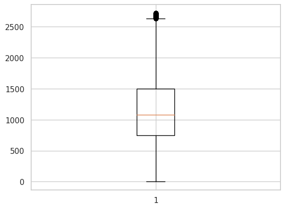

```python
plt.boxplot(df.population);
```

```python
#Removing outliers for households column
Q1_households = df['households'].quantile(0.25)
Q3_households = df['households'].quantile(0.75)
IQR = Q3_households - Q1_households

df= df[(df['households'] > Q1_households - 1.5 * IQR) & (df['households'] < Q3_households + 1.5 * IQR)]
```

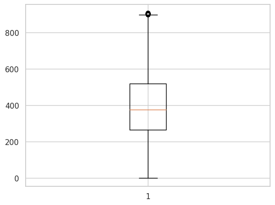

```python
plt.boxplot(df.households);
```

```python
#Removing outliers for median_income column
Q1_median_income = df['median_income'].quantile(0.25)
Q3_median_income = df['median_income'].quantile(0.75)
IQR = Q3_median_income - Q1_median_income

df= df[(df['median_income'] > Q1_median_income - 1.5 * IQR) & (df['median_income'] < Q3_median_income + 1.5 * IQR)]
```

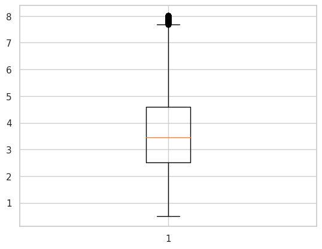

```python
plt.boxplot(df.median_income);
```

```python
#Removing outliers for median_house_value column
Q1_median_house_value = df['median_house_value'].quantile(0.25)
Q3_median_house_value = df['median_house_value'].quantile(0.75)
IQR = Q3_median_house_value - Q1_median_house_value

df= df[(df['median_house_value'] > Q1_median_house_value - 1.5 * IQR) & (df['median_house_value'] < Q3_median_house_value + 1.5 * IQR)]
```

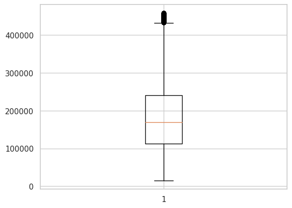

```python
plt.boxplot(df.median_house_value);
```

### 3.4 Encode the categorical variable ocean proximity using Label encoder or One hot encoder

```python
from sklearn.preprocessing import LabelEncoder

label_encoder = LabelEncoder()
df['ocean_proximity_encoded'] = label_encoder.fit_transform(df['ocean_proximity'])
```

```python
df.head()
```

|  | longitude | latitude | housing_median_age | total_rooms | total_bedrooms | population | households | median_income | median_house_value | ocean_proximity | ocean_proximity_encoded |
| --- | --- | --- | --- | --- | --- | --- | --- | --- | --- | --- | --- |
| 2 | -122.24 | 37.85 | 52.0 | 1467.0 | 190.0 | 496.0 | 177.0 | 7.2574 | 352100.0 | NEAR BAY | 3 |
| 3 | -122.25 | 37.85 | 52.0 | 1274.0 | 235.0 | 558.0 | 219.0 | 5.6431 | 341300.0 | NEAR BAY | 3 |
| 4 | -122.25 | 37.85 | 52.0 | 1627.0 | 280.0 | 565.0 | 259.0 | 3.8462 | 342200.0 | NEAR BAY | 3 |
| 5 | -122.25 | 37.85 | 52.0 | 919.0 | 213.0 | 413.0 | 193.0 | 4.0368 | 269700.0 | NEAR BAY | 3 |
| 6 | -122.25 | 37.84 | 52.0 | 2535.0 | 489.0 | 1094.0 | 514.0 | 3.6591 | 299200.0 | NEAR BAY | 3 |

## Section 4. Splitting the dataset

```python
target = df[['median_house_value']]
```

```python
df= df.drop('median_house_value', axis=1)
```

```python
df.shape
```

```
(16896, 10)
```

# Taking the independent (X) variable as housing_median_age

### 4.2 Split df into X_train and X_test with test ratio 0.2. Similar create y_train and y_test.

## 4.3 Plot histogram distribution of y_train and y_test and check whether they follow similar distribution.

```python
import pandas as pd
import numpy as np
from sklearn.model_selection import train_test_split
from sklearn.linear_model import LinearRegression

# Split the data into X (features) and y (target)
X = df['housing_median_age']
y = target

# Split the data into training and testing sets
X_train, X_test, y_train, y_test = train_test_split(X, y, test_size=0.2, random_state=42)

# Check the shapes of the resulting sets
print("X_train shape:", X_train.shape)
print("X_test shape:", X_test.shape)
print("y_train shape:", y_train.shape)
print("y_test shape:", y_test.shape)
```

```
X_train shape: (13516,)
X_test shape: (3380,)
y_train shape: (13516, 1)
y_test shape: (3380, 1)
```

```python
print(type(X_train))
print(type(y_train))
```

```
<class 'pandas.core.series.Series'>
<class 'pandas.core.frame.DataFrame'>
```

```python
# Converting the Pandas dataframe to a numpyarray and then reshaping it
X_train = X_train.to_numpy().reshape(-1, 1)
X_test = X_test.to_numpy().reshape(-1, 1)
#y_train = y_train.to_numpy().reshape(-1, 1)
#y_test = y_test.to_numpy().reshape(-1, 1)
```

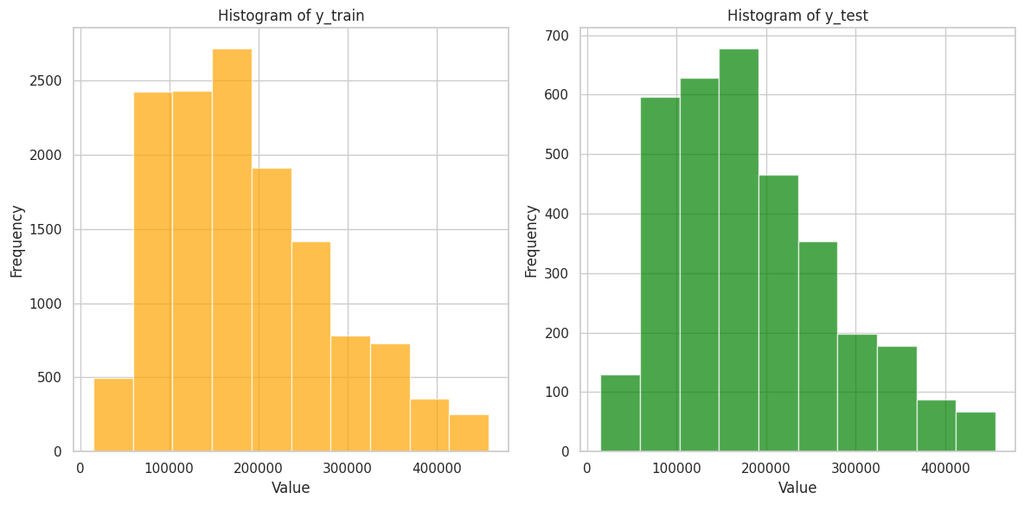

```python
import matplotlib.pyplot as plt

# Plot histogram of y_train
plt.figure(figsize=(12, 6))
plt.subplot(1, 2, 1)
plt.hist(y_train, bins=10, color='orange', alpha=0.7)
plt.title("Histogram of y_train")
plt.xlabel("Value")
plt.ylabel("Frequency")

# Plot histogram of y_test
plt.subplot(1, 2, 2)
plt.hist(y_test, bins=10, color='green', alpha=0.7)
plt.title("Histogram of y_test")
plt.xlabel("Value")
plt.ylabel("Frequency")

plt.tight_layout()
plt.show()
```

- The distribution pattern is similar but there is a difference in frequency of both the Histograms with y_train having higher frequency since it is 80% of the dataset.

## **Section 5. Training the model**

### 5.1 Define a Linear regression model and fit(train) the model only on train data.

```python
from sklearn.linear_model import LinearRegression
linear_model = LinearRegression()
linear_model.fit(X_train, y_train)
```

```
LinearRegression()
```

```python
y_pred = (linear_model.predict(X_test))
```

```python
from sklearn import metrics
from sklearn.metrics import r2_score

r_squared = r2_score(y_test, y_pred)
print('Mean Squared Error housing_median_age:', metrics.mean_squared_error(y_test, y_pred))
print('R square error: ', r_squared)
```

```
Mean Squared Error housing_median_age: 8350277468.743956
R square error:  0.005454892667200895
```

# Taking the independent (X) variable as population

```python
import pandas as pd
import numpy as np
from sklearn.model_selection import train_test_split
from sklearn.linear_model import LinearRegression

# Split the data into X (features) and y (target)
X = df['population']
y = target

# Split the data into training and testing sets
X_train, X_test, y_train, y_test = train_test_split(X, y, test_size=0.2, random_state=42)

# Check the shapes of the resulting sets
print("X_train shape:", X_train.shape)
print("X_test shape:", X_test.shape)
print("y_train shape:", y_train.shape)
print("y_test shape:", y_test.shape)


# Converting the Pandas dataframe to a numpyarray and then reshaping it
X_train = X_train.to_numpy().reshape(-1, 1)
X_test = X_test.to_numpy().reshape(-1, 1)
#y_train = y_train.to_numpy().reshape(-1, 1)
#y_test = y_test.to_numpy().reshape(-1, 1)
```

```
X_train shape: (13516,)
X_test shape: (3380,)
y_train shape: (13516, 1)
y_test shape: (3380, 1)
```

```python
#Defining Linear regression model
from sklearn.linear_model import LinearRegression
linear_model = LinearRegression()
linear_model.fit(X_train, y_train)
```

```
LinearRegression()
```

```python
y_pred = (linear_model.predict(X_test))
```

```python
from sklearn import metrics
from sklearn.metrics import r2_score

r_squared = r2_score(y_test, y_pred)
print('Mean Squared Error population:', metrics.mean_squared_error(y_test, y_pred))
print('R square error: ', r_squared)
```

```
Mean Squared Error population: 8396130693.320491
R square error:  -6.374976745382455e-06
```

# Taking the independent (X) variable as total_rooms

```python
import pandas as pd
import numpy as np
from sklearn.model_selection import train_test_split
from sklearn.linear_model import LinearRegression

# Split the data into X (features) and y (target)
X = df['total_rooms']
y = target

# Split the data into training and testing sets
X_train, X_test, y_train, y_test = train_test_split(X, y, test_size=0.2, random_state=42)

# Check the shapes of the resulting sets
print("X_train shape:", X_train.shape)
print("X_test shape:", X_test.shape)
print("y_train shape:", y_train.shape)
print("y_test shape:", y_test.shape)


# Converting the Pandas dataframe to a numpyarray and then reshaping it
X_train = X_train.to_numpy().reshape(-1, 1)
X_test = X_test.to_numpy().reshape(-1, 1)
#y_train = y_train.to_numpy().reshape(-1, 1)
#y_test = y_test.to_numpy().reshape(-1, 1)
```

```
X_train shape: (13516,)
X_test shape: (3380,)
y_train shape: (13516, 1)
y_test shape: (3380, 1)
```

```python
#Defining Linear regression model
from sklearn.linear_model import LinearRegression
linear_model = LinearRegression()
linear_model.fit(X_train, y_train)
```

```
LinearRegression()
```

```python
y_pred = (linear_model.predict(X_test))
```

```python
from sklearn import metrics
from sklearn.metrics import r2_score

r_squared = r2_score(y_test, y_pred)
print('Mean Squared Error total_rooms:', metrics.mean_squared_error(y_test, y_pred))
print('R square error: ', r_squared)
```

```
Mean Squared Error total_rooms: 8117245672.036712
R square error:  0.03320973484288514
```

# Taking the independent (X) variable as total_bedrooms

```python
import pandas as pd
import numpy as np
from sklearn.model_selection import train_test_split
from sklearn.linear_model import LinearRegression

# Split the data into X (features) and y (target)
X = df['total_bedrooms']
y = target

# Split the data into training and testing sets
X_train, X_test, y_train, y_test = train_test_split(X, y, test_size=0.2, random_state=42)

# Check the shapes of the resulting sets
print("X_train shape:", X_train.shape)
print("X_test shape:", X_test.shape)
print("y_train shape:", y_train.shape)
print("y_test shape:", y_test.shape)
```

```
X_train shape: (13516,)
X_test shape: (3380,)
y_train shape: (13516, 1)
y_test shape: (3380, 1)
```

```python
# Converting the Pandas dataframe to a numpyarray and then reshaping it
X_train = X_train.to_numpy().reshape(-1, 1)
X_test = X_test.to_numpy().reshape(-1, 1)
#y_train = y_train.to_numpy().reshape(-1, 1)
#y_test = y_test.to_numpy().reshape(-1, 1)
```

```python
#Defining Linear regression model
from sklearn.linear_model import LinearRegression
linear_model = LinearRegression()
linear_model.fit(X_train, y_train)
```

```
LinearRegression()
```

```python
y_pred = (linear_model.predict(X_test))
```

```python
from sklearn import metrics
from sklearn.metrics import r2_score

r_squared = r2_score(y_test, y_pred)
print('Mean Squared Error total_bedrooms:', metrics.mean_squared_error(y_test, y_pred))
print('R square error: ', r_squared)
```

```
Mean Squared Error total_bedrooms: 8366892486.187019
R square error:  0.0034759902453231906
```

# Taking the independent (X) variable as households

```python
import pandas as pd
import numpy as np
from sklearn.model_selection import train_test_split
from sklearn.linear_model import LinearRegression

# Split the data into X (features) and y (target)
X = df['households']
y = target

# Split the data into training and testing sets
X_train, X_test, y_train, y_test = train_test_split(X, y, test_size=0.2, random_state=42)

# Check the shapes of the resulting sets
print("X_train shape:", X_train.shape)
print("X_test shape:", X_test.shape)
print("y_train shape:", y_train.shape)
print("y_test shape:", y_test.shape)
```

```
X_train shape: (13516,)
X_test shape: (3380,)
y_train shape: (13516, 1)
y_test shape: (3380, 1)
```

```python
# Converting the Pandas dataframe to a numpyarray and then reshaping it
X_train = X_train.to_numpy().reshape(-1, 1)
X_test = X_test.to_numpy().reshape(-1, 1)
#y_train = y_train.to_numpy().reshape(-1, 1)
#y_test = y_test.to_numpy().reshape(-1, 1)
```

```python
#Defining Linear regression model
from sklearn.linear_model import LinearRegression
linear_model = LinearRegression()
linear_model.fit(X_train, y_train)
```

```
LinearRegression()
```

```python
y_pred = (linear_model.predict(X_test))
```

```python
from sklearn import metrics
from sklearn.metrics import r2_score

r_squared = r2_score(y_test, y_pred)
print('Mean Squared Error households:', metrics.mean_squared_error(y_test, y_pred))
print('R square error: ', r_squared)
```

```
Mean Squared Error households: 8323377823.318959
R square error:  0.008658727611196015
```

# Taking the independent (X) variable as median_income

```python
import pandas as pd
import numpy as np
from sklearn.model_selection import train_test_split
from sklearn.linear_model import LinearRegression

# Split the data into X (features) and y (target)
X = df['median_income']
y = target

# Split the data into training and testing sets
X_train, X_test, y_train, y_test = train_test_split(X, y, test_size=0.2, random_state=42)

# Check the shapes of the resulting sets
print("X_train shape:", X_train.shape)
print("X_test shape:", X_test.shape)
print("y_train shape:", y_train.shape)
print("y_test shape:", y_test.shape)
```

```
X_train shape: (13516,)
X_test shape: (3380,)
y_train shape: (13516, 1)
y_test shape: (3380, 1)
```

```python
# Converting the Pandas dataframe to a numpyarray and then reshaping it
X_train = X_train.to_numpy().reshape(-1, 1)
X_test = X_test.to_numpy().reshape(-1, 1)
#y_train = y_train.to_numpy().reshape(-1, 1)
#y_test = y_test.to_numpy().reshape(-1, 1)
```

```python
#Defining Linear regression model
from sklearn.linear_model import LinearRegression
linear_model = LinearRegression()
linear_model.fit(X_train, y_train)
```

```
LinearRegression()
```

```python
y_pred = (linear_model.predict(X_test))
```

```python
from sklearn import metrics
from sklearn.metrics import r2_score

r_squared = r2_score(y_test, y_pred)
print('Mean Squared Error median_income:', metrics.mean_squared_error(y_test, y_pred))
print('R square error: ', r_squared)
```

```
Mean Squared Error median_income: 4989726508.082182
R square error:  0.4057074026441465
```

- Mean Squared Error **housing_median_age**: 8350277468.743956

  R square error: 0.005454892667200895
- Mean Squared Error **population**: 8396130693.320491

  R square error: -6.374976745382455e-06
- Mean Squared Error **total_rooms**: 8117245672.036712

  R square error: 0.03320973484288514
- Mean Squared Error **total_bedrooms**: 8366892486.187019

  R square error: 0.0034759902453231906
- Mean Squared Error **households**: 8323377823.318959

  R square error: 0.008658727611196015
- Mean Squared Error **median_income**: 4989726508.082182

  R square error: 0.4057074026441465
- It can be observed that a lower MSE indicates a model is better fit for our analyis.
- Similarly a higher R-squared value also means a model is better fit and a positive R squared value indicates that the model has some variance with the related feature whereas a negative value indicates the model is worse performing.
- Based on the above scores the median_income has higher R-sqaured value of 0.4057 indicating the it is best fit for the model and this can also be verified with the correlation matrix.
- total_rooms, housing_median_age and householdshave a positive R-sqaured values but does not have much influence on the variance of the model.
- population and total_bedrooms have a R -sqaured value of nearly zero indicating that they do not have any significance variance on the model.

# **Section 6. Feature importance and Feature selection**

square and mean_squared_error

```python
import pandas as pd
import numpy as np
from sklearn.model_selection import train_test_split
from sklearn.linear_model import LinearRegression

# Split the data into X (features) and y (target)
X = df[['median_income', 'total_rooms','housing_median_age']]
y = target

# Split the data into training and testing sets
X_train, X_test, y_train, y_test = train_test_split(X, y, test_size=0.2, random_state=42)

# Check the shapes of the resulting sets
print("X_train shape:", X_train.shape)
print("X_test shape:", X_test.shape)
print("y_train shape:", y_train.shape)
print("y_test shape:", y_test.shape)
```

```
X_train shape: (13516, 3)
X_test shape: (3380, 3)
y_train shape: (13516, 1)
y_test shape: (3380, 1)
```

```python
#Defining Linear regression model
from sklearn.linear_model import LinearRegression
linear_model = LinearRegression()
linear_model.fit(X_train, y_train)
```

```
LinearRegression()
```

```python
y_pred = (linear_model.predict(X_test))
```

```python
from sklearn import metrics
from sklearn.metrics import r2_score

r_squared = r2_score(y_test, y_pred)
print('Mean Squared Error top_3_features:', metrics.mean_squared_error(y_test, y_pred))
print('R square error: ', r_squared)
```

```
Mean Squared Error top_3_features: 4648262178.974342
R square error:  0.4463769108268443
```

```python
df= df.drop('ocean_proximity', axis=1)
```

```python
df.head()
```

|  | longitude | latitude | housing_median_age | total_rooms | total_bedrooms | population | households | median_income | ocean_proximity_encoded |
| --- | --- | --- | --- | --- | --- | --- | --- | --- | --- |
| 2 | -122.24 | 37.85 | 52.0 | 1467.0 | 190.0 | 496.0 | 177.0 | 7.2574 | 3 |
| 3 | -122.25 | 37.85 | 52.0 | 1274.0 | 235.0 | 558.0 | 219.0 | 5.6431 | 3 |
| 4 | -122.25 | 37.85 | 52.0 | 1627.0 | 280.0 | 565.0 | 259.0 | 3.8462 | 3 |
| 5 | -122.25 | 37.85 | 52.0 | 919.0 | 213.0 | 413.0 | 193.0 | 4.0368 | 3 |
| 6 | -122.25 | 37.84 | 52.0 | 2535.0 | 489.0 | 1094.0 | 514.0 | 3.6591 | 3 |

### 6.3 Compare the performance of the original model (using all the features) with the current model.

## Comparing the model with all features in the dataframe

```python
import pandas as pd
import numpy as np
from sklearn.model_selection import train_test_split
from sklearn.linear_model import LinearRegression

# Split the data into X (features) and y (target)
X = df
y = target

# Split the data into training and testing sets
X_train, X_test, y_train, y_test = train_test_split(X, y, test_size=0.2, random_state=42)

# Check the shapes of the resulting sets
print("X_train shape:", X_train.shape)
print("X_test shape:", X_test.shape)
print("y_train shape:", y_train.shape)
print("y_test shape:", y_test.shape)
```

```
X_train shape: (13516, 9)
X_test shape: (3380, 9)
y_train shape: (13516, 1)
y_test shape: (3380, 1)
```

```python
#Defining Linear regression model
from sklearn.linear_model import LinearRegression
linear_model = LinearRegression()
linear_model.fit(X_train, y_train)
```

```
LinearRegression()
```

```python
y_pred = (linear_model.predict(X_test))
```

```python
from sklearn import metrics
from sklearn.metrics import r2_score

r_squared = r2_score(y_test, y_pred)
print('Mean Squared Error dataframe:', metrics.mean_squared_error(y_test, y_pred))
print('R square error: ', r_squared)
```

```
Mean Squared Error dataframe: 3373656771.6315527
R square error:  0.5981865454644559
```

Thus our whole dataframe model is a better fit than the top 3 feature model for the target variable.